# Portfolio Project: Online Retail Exploratory Data Analysis with Python

## Overview

In this project, you will step into the shoes of an entry-level data analyst at an online retail company, helping interpret real-world data to help make a key business decision.

## Case Study

In this project, you will be working with transactional data from an online retail store. The dataset contains information about customer purchases, including product details, quantities, prices, and timestamps. Your task is to explore and analyze this dataset to gain insights into the store's sales trends, customer behavior, and popular products.

By conducting exploratory data analysis, you will identify patterns, outliers, and correlations in the data, allowing you to make data-driven decisions and recommendations to optimize the store's operations and improve customer satisfaction. Through visualizations and statistical analysis, you will uncover key trends, such as the busiest sales months, best-selling products, and the store's most valuable customers. Ultimately, this project aims to provide actionable insights that can drive strategic business decisions and enhance the store's overall performance in the competitive online retail market.

## Prerequisites

Before starting this project, you should have some basic knowledge of Python programming and Pandas. In addition, you may want to use the following packages in your Python environment:

- pandas
- numpy
- seaborn
- matplotlib

These packages should already be installed in Coursera's Jupyter Notebook environment, however if you'd like to install additional packages that are not included in this environment or are working off platform you can install additional packages using `!pip install packagename` within a notebook cell such as:

- `!pip install pandas`
- `!pip install matplotlib`

## Project Objectives

1. Describe data to answer key questions to uncover insights
2. Gain valuable insights that will help improve online retail performance
3. Provide analytic insights and data-driven recommendations

## Dataset

The dataset you will be working with is the "Online Retail" dataset. It contains transactional data of an online retail store from 2010 to 2011. The dataset is available as a .xlsx file named `Online Retail.xlsx`. This data file is already included in the Coursera Jupyter Notebook environment, however if you are working off-platform it can also be downloaded [here](https://archive.ics.uci.edu/ml/machine-learning-databases/00352/Online%20Retail.xlsx).

The dataset contains the following columns:

- InvoiceNo: Invoice number of the transaction
- StockCode: Unique code of the product
- Description: Description of the product
- Quantity: Quantity of the product in the transaction
- InvoiceDate: Date and time of the transaction
- UnitPrice: Unit price of the product
- CustomerID: Unique identifier of the customer
- Country: Country where the transaction occurred

## Tasks

You may explore this dataset in any way you would like - however if you'd like some help getting started, here are a few ideas:

1. Load the dataset into a Pandas DataFrame and display the first few rows to get an overview of the data.
2. Perform data cleaning by handling missing values, if any, and removing any redundant or unnecessary columns.
3. Explore the basic statistics of the dataset, including measures of central tendency and dispersion.
4. Perform data visualization to gain insights into the dataset. Generate appropriate plots, such as histograms, scatter plots, or bar plots, to visualize different aspects of the data.
5. Analyze the sales trends over time. Identify the busiest months and days of the week in terms of sales.
6. Explore the top-selling products and countries based on the quantity sold.
7. Identify any outliers or anomalies in the dataset and discuss their potential impact on the analysis.
8. Draw conclusions and summarize your findings from the exploratory data analysis.

## Task 1: Load the Data

```python
# your code here
import pandas as pd
import numpy as np
import matplotlib.pyplot as plt
import seaborn as sns
from datetime import datetime
```

```python
df = pd.read_excel('Online Retail.xlsx')
```

:Viewing the Data

```python
df.head()
```

|  | InvoiceNo | StockCode | Description | Quantity | InvoiceDate | UnitPrice | CustomerID | Country |
| --- | --- | --- | --- | --- | --- | --- | --- | --- |
| 0 | 536365 | 85123A | WHITE HANGING HEART T-LIGHT HOLDER | 6 | 2010-12-01 08:26:00 | 2.55 | 17850.0 | United Kingdom |
| 1 | 536365 | 71053 | WHITE METAL LANTERN | 6 | 2010-12-01 08:26:00 | 3.39 | 17850.0 | United Kingdom |
| 2 | 536365 | 84406B | CREAM CUPID HEARTS COAT HANGER | 8 | 2010-12-01 08:26:00 | 2.75 | 17850.0 | United Kingdom |
| 3 | 536365 | 84029G | KNITTED UNION FLAG HOT WATER BOTTLE | 6 | 2010-12-01 08:26:00 | 3.39 | 17850.0 | United Kingdom |
| 4 | 536365 | 84029E | RED WOOLLY HOTTIE WHITE HEART. | 6 | 2010-12-01 08:26:00 | 3.39 | 17850.0 | United Kingdom |

```python
df.tail()
```

|  | InvoiceNo | StockCode | Description | Quantity | InvoiceDate | UnitPrice | CustomerID | Country |
| --- | --- | --- | --- | --- | --- | --- | --- | --- |
| 541904 | 581587 | 22613 | PACK OF 20 SPACEBOY NAPKINS | 12 | 2011-12-09 12:50:00 | 0.85 | 12680.0 | France |
| 541905 | 581587 | 22899 | CHILDREN'S APRON DOLLY GIRL | 6 | 2011-12-09 12:50:00 | 2.10 | 12680.0 | France |
| 541906 | 581587 | 23254 | CHILDRENS CUTLERY DOLLY GIRL | 4 | 2011-12-09 12:50:00 | 4.15 | 12680.0 | France |
| 541907 | 581587 | 23255 | CHILDRENS CUTLERY CIRCUS PARADE | 4 | 2011-12-09 12:50:00 | 4.15 | 12680.0 | France |
| 541908 | 581587 | 22138 | BAKING SET 9 PIECE RETROSPOT | 3 | 2011-12-09 12:50:00 | 4.95 | 12680.0 | France |

:Look at Metadata

```python
df.shape
```

```
(541909, 8)
```

```python
df.dtypes
```

```
InvoiceNo              object
StockCode              object
Description            object
Quantity                int64
InvoiceDate    datetime64[ns]
UnitPrice             float64
CustomerID            float64
Country                object
dtype: object
```

```python
df.count()
```

```
InvoiceNo      541909
StockCode      541909
Description    540455
Quantity       541909
InvoiceDate    541909
UnitPrice      541909
CustomerID     406829
Country        541909
dtype: int64
```

### Task 2. Perform Data Cleaning

```python
df[df.duplicated()].head()
```

|  | InvoiceNo | StockCode | Description | Quantity | InvoiceDate | UnitPrice | CustomerID | Country |
| --- | --- | --- | --- | --- | --- | --- | --- | --- |
| 517 | 536409 | 21866 | UNION JACK FLAG LUGGAGE TAG | 1 | 2010-12-01 11:45:00 | 1.25 | 17908.0 | United Kingdom |
| 527 | 536409 | 22866 | HAND WARMER SCOTTY DOG DESIGN | 1 | 2010-12-01 11:45:00 | 2.10 | 17908.0 | United Kingdom |
| 537 | 536409 | 22900 | SET 2 TEA TOWELS I LOVE LONDON | 1 | 2010-12-01 11:45:00 | 2.95 | 17908.0 | United Kingdom |
| 539 | 536409 | 22111 | SCOTTIE DOG HOT WATER BOTTLE | 1 | 2010-12-01 11:45:00 | 4.95 | 17908.0 | United Kingdom |
| 555 | 536412 | 22327 | ROUND SNACK BOXES SET OF 4 SKULLS | 1 | 2010-12-01 11:49:00 | 2.95 | 17920.0 | United Kingdom |

```python
df[df['StockCode']==22900].head()
```

|  | InvoiceNo | StockCode | Description | Quantity | InvoiceDate | UnitPrice | CustomerID | Country |
| --- | --- | --- | --- | --- | --- | --- | --- | --- |
| 40 | 536370 | 22900 | SET 2 TEA TOWELS I LOVE LONDON | 24 | 2010-12-01 08:45:00 | 2.95 | 12583.0 | France |
| 521 | 536409 | 22900 | SET 2 TEA TOWELS I LOVE LONDON | 1 | 2010-12-01 11:45:00 | 2.95 | 17908.0 | United Kingdom |
| 537 | 536409 | 22900 | SET 2 TEA TOWELS I LOVE LONDON | 1 | 2010-12-01 11:45:00 | 2.95 | 17908.0 | United Kingdom |
| 611 | 536412 | 22900 | SET 2 TEA TOWELS I LOVE LONDON | 2 | 2010-12-01 11:49:00 | 2.95 | 17920.0 | United Kingdom |
| 617 | 536412 | 22900 | SET 2 TEA TOWELS I LOVE LONDON | 2 | 2010-12-01 11:49:00 | 2.95 | 17920.0 | United Kingdom |

```python
# drop the duplicate entries
df.drop_duplicates(inplace=True)
```

```python
df.shape
```

```
(536641, 8)
```

```python
#Check Missing/Null values
df.isnull().sum()
```

```
InvoiceNo           0
StockCode           0
Description      1454
Quantity            0
InvoiceDate         0
UnitPrice           0
CustomerID     135037
Country             0
dtype: int64
```

```python
# drop the missing fields
df['CustomerID'].dropna(inplace=True)
```

```python
df.drop(df[df['Quantity']<0].index,inplace=True)
```

```python
df.shape
```

```
(526054, 8)
```

```python
df['InvoiceDate'] = pd.to_datetime(df['InvoiceDate'])
```

:Extracting Month and Day from Date

```python
df['month'] = df['InvoiceDate'].dt.month
df['day'] = df['InvoiceDate'].dt.weekday
```

```python
df['InvoiceDate'].dt.weekday
```

```
0         2
1         2
2         2
3         2
4         2
         ..
541904    4
541905    4
541906    4
541907    4
541908    4
Name: InvoiceDate, Length: 526054, dtype: int64
```

```python
df['TotalSales'] = df['Quantity']*df['UnitPrice']
df['TotalSales'] = df['TotalSales'].round(2)
```

```python
df.head()
```

|  | InvoiceNo | StockCode | Description | Quantity | InvoiceDate | UnitPrice | CustomerID | Country | month | day | TotalSales |
| --- | --- | --- | --- | --- | --- | --- | --- | --- | --- | --- | --- |
| 0 | 536365 | 85123A | WHITE HANGING HEART T-LIGHT HOLDER | 6 | 2010-12-01 08:26:00 | 2.55 | 17850.0 | United Kingdom | 12 | 2 | 15.30 |
| 1 | 536365 | 71053 | WHITE METAL LANTERN | 6 | 2010-12-01 08:26:00 | 3.39 | 17850.0 | United Kingdom | 12 | 2 | 20.34 |
| 2 | 536365 | 84406B | CREAM CUPID HEARTS COAT HANGER | 8 | 2010-12-01 08:26:00 | 2.75 | 17850.0 | United Kingdom | 12 | 2 | 22.00 |
| 3 | 536365 | 84029G | KNITTED UNION FLAG HOT WATER BOTTLE | 6 | 2010-12-01 08:26:00 | 3.39 | 17850.0 | United Kingdom | 12 | 2 | 20.34 |
| 4 | 536365 | 84029E | RED WOOLLY HOTTIE WHITE HEART. | 6 | 2010-12-01 08:26:00 | 3.39 | 17850.0 | United Kingdom | 12 | 2 | 20.34 |

### Task 3. Explore Basic Statistics

```python
#basic statistics
df.describe()
```

|  | Quantity | UnitPrice | CustomerID | month | day | TotalSales |
| --- | --- | --- | --- | --- | --- | --- |
| count | 526054.000000 | 526054.000000 | 392732.000000 | 526054.000000 | 526054.000000 | 526054.000000 |
| mean | 10.730874 | 3.871747 | 15287.734822 | 7.551879 | 2.428091 | 20.188016 |
| std | 157.591838 | 42.016560 | 1713.567773 | 3.508391 | 1.844960 | 272.250300 |
| min | 1.000000 | -11062.060000 | 12346.000000 | 1.000000 | 0.000000 | -11062.060000 |
| 25% | 1.000000 | 1.250000 | 13955.000000 | 5.000000 | 1.000000 | 3.900000 |
| 50% | 4.000000 | 2.080000 | 15150.000000 | 8.000000 | 2.000000 | 9.920000 |
| 75% | 11.000000 | 4.130000 | 16791.000000 | 11.000000 | 4.000000 | 17.700000 |
| max | 80995.000000 | 13541.330000 | 18287.000000 | 12.000000 | 6.000000 | 168469.600000 |

### Task 4. Perform Data Viz

:Checking Outliers

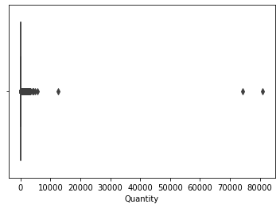

```python
sns.boxplot(x=df['Quantity'])
```

```python
#Drop rows with outliers
df = df.drop(df[df['Quantity'] > 70000].index)
```

[figure not shown]

```python
sns.boxplot(x=df['UnitPrice'])
```

```python
# remove the outlier
df = df.drop(df[df['UnitPrice']>7000].index)
df = df.drop(df[df['UnitPrice']<0].index)
```

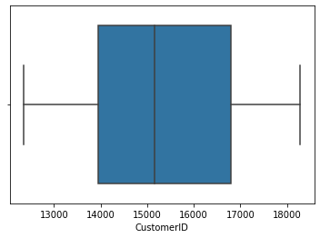

```python
sns.boxplot(x=df['CustomerID'])
```

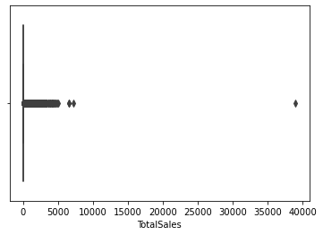

```python
sns.boxplot(x=df['TotalSales'])
```

> Outliers can lead to a shift in the IQR range and the mean values thereby causing anomalies in the analysis.

:Top Orders by Country

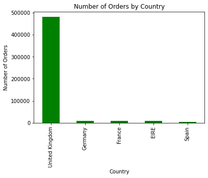

```python
df['Country'].value_counts().nlargest(5).plot(kind='bar',color='g')
plt.title("Number of Orders by Country")
plt.ylabel('Number of Orders')
plt.xlabel('Country')
```

> We conclude, the United Kingdom ranked first in most online purchases.

:Viewing Number of Orders by Unit Price

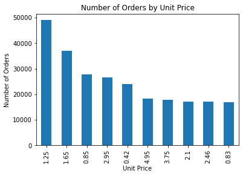

```python
df['UnitPrice'].value_counts().nlargest(10).plot(kind='bar')
plt.title("Number of Orders by Unit Price")
plt.ylabel('Number of Orders')
plt.xlabel('Unit Price')
```

:Viewing Number of Orders by Quantity

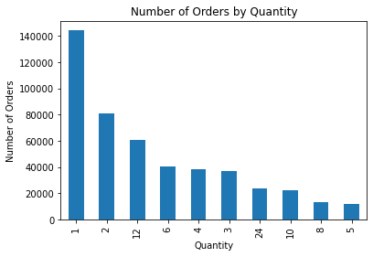

```python
df['Quantity'].value_counts().nlargest(10).plot(kind='bar')
plt.title("Number of Orders by Quantity")
plt.ylabel('Number of Orders')
plt.xlabel('Quantity')
```

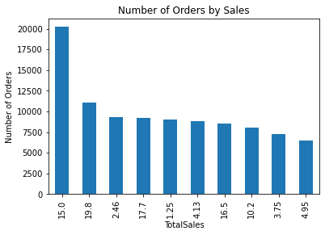

```python
df['TotalSales'].value_counts().nlargest(10).plot(kind='bar')
plt.title("Number of Orders by Sales")
plt.ylabel('Number of Orders')
plt.xlabel('TotalSales')
```

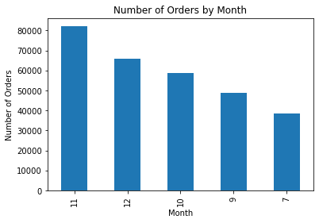

```python
df['month'].value_counts().nlargest(5).plot(kind='bar')
plt.title("Number of Orders by Month")
plt.ylabel('Number of Orders')
plt.xlabel('Month')
```

> We note from above chart that most orders generated were from following months: November, December, October, September and July.

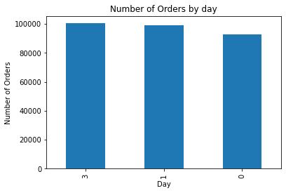

```python
df['day'].value_counts().nlargest(3).plot(kind='bar')
plt.title("Number of Orders by day")
plt.ylabel('Number of Orders')
plt.xlabel('Day')
```

:HeatMaps

> They are used to find relationship between UnitPrice and variables (Quantity, CustomerID)

|  | Quantity | UnitPrice | CustomerID | month | day | TotalSales |
| --- | --- | --- | --- | --- | --- | --- |
| Quantity | 1.000000 | -0.019302 | -0.019846 | -0.006958 | -0.009150 | 0.424714 |
| UnitPrice | -0.019302 | 1.000000 | -0.013789 | -0.000422 | -0.013765 | 0.299498 |
| CustomerID | -0.019846 | -0.013789 | 1.000000 | 0.029632 | 0.019831 | -0.012225 |
| month | -0.006958 | -0.000422 | 0.029632 | 1.000000 | 0.040742 | -0.000318 |
| day | -0.009150 | -0.013765 | 0.019831 | 0.040742 | 1.000000 | -0.015541 |
| TotalSales | 0.424714 | 0.299498 | -0.012225 | -0.000318 | -0.015541 | 1.000000 |

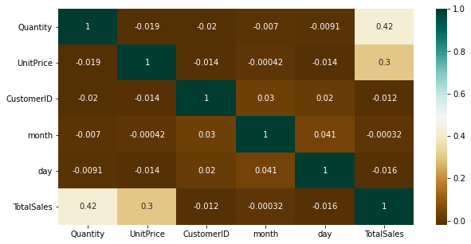

```python
plt.figure(figsize=(10,5))
c= df.corr()
sns.heatmap(c,cmap="BrBG",annot=True)
c
```

:ScatterPlot

> Find Correlation between two variables

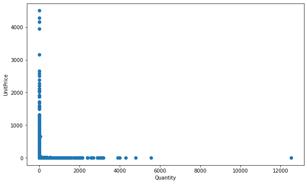

```python
fig, ax = plt.subplots(figsize=(10,6))
ax.scatter(df['Quantity'], df['UnitPrice'])
ax.set_xlabel('Quantity')
ax.set_ylabel('UnitPrice')
plt.show()
```

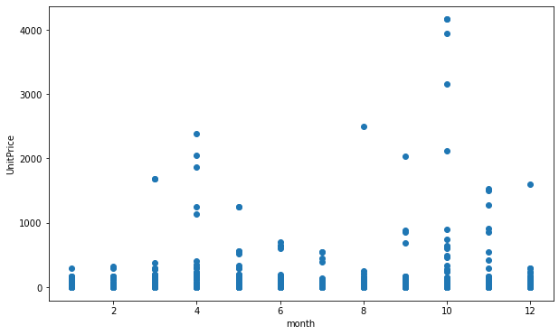

```python
fig, ax = plt.subplots(figsize=(10,6))
ax.scatter(df['month'], df['UnitPrice'])
ax.set_xlabel('month')
ax.set_ylabel('UnitPrice')
plt.show()
```

[figure not shown]

```python
fig, ax = plt.subplots(figsize=(10,6))
ax.scatter(df['day'], df['UnitPrice'])
ax.set_xlabel('day')
ax.set_ylabel('UnitPrice')
plt.show()
```